# Taller 2.1 (corregido) - Diagnóstico multivariado de las 33 variables

Luisa Fernanda Velasco López 20212020106 Jairo Arturo Barrera Mosquera 20222020142 David lugo Piñeros 20222020180 Gabriela Martínez Silva 20231020205

2026-10-31

Este documento revisa las **33 variables** de `data/raw/educacion_limpio.csv` (30 indicadores numéricos, `AÑO`, `DEPARTAMENTO` y `MUNICIPIO`) para covarianzas, correlaciones y distancias de Mahalanobis. Los 30 indicadores entran a las matrices de covarianza y correlación y a Mahalanobis; las 3 categóricas se incorporan mediante su asociación con los indicadores (Taller 1) y como columnas one-hot (sección 2.1). Usa **solo `data/raw/educacion_limpio.csv`**. Todos los resultados se regeneran en `outputs/taller-02/tables` y `outputs/taller-02/figures`.

## 0. Qué se corrigió respecto a la versión anterior

[output not shown]

## 1. Carga, tipos y selección de indicadores

```r
datos <- cargar_educacion(project_root)
indicadores <- columnas_indicadores(datos)
X <- datos[, indicadores]
panel <- resumen_panel(datos)

es_constante <- vapply(X, function(v) length(unique(v)) <= 1, logical(1))
columnas_constantes <- indicadores[es_constante]
duplicados <- sum(duplicated(datos[, c("AÑO", "ID_MUNICIPIO")]))

# Comprobaciones: si el archivo cambia, el informe falla en vez de mostrar cifras viejas.
stopifnot(!"AÑO" %in% names(X), ncol(X) == 30, nrow(X) == nrow(datos),
          !anyNA(X), duplicados == 0)

write.csv(data.frame(Variable = columnas_constantes,
                     Motivo = rep("Constante o sin variación", length(columnas_constantes))),
          file.path(tables_dir, "Columnas_excluidas.csv"), row.names = FALSE)
X <- X[, !es_constante, drop = FALSE]
write.csv(data.frame(Variable = names(X)), file.path(tables_dir, "Variables_usadas.csv"), row.names = FALSE)
```

`AÑO`, `MUNICIPIO` y `DEPARTAMENTO` son identificadores/categorías y no participan. Se usan **30 indicadores** sobre **13.802 registros municipio-año** de **1.123 municipios**. Columnas constantes excluidas: ninguna. Filas duplicadas por municipio-año: 0.

## 2. Tamaño, faltantes y condicionamiento

```r
R <- cor(X)
autovalores <- eigen(R, symmetric = TRUE, only.values = TRUE)$values
suma_tres <- datos$APROBACIÓN + datos$REPROBACIÓN + datos$DESERCIÓN
# Registros con TODOS los indicadores de tasa en cero (solo la población es positiva)
tasas <- setdiff(names(X), "POBLACIÓN_5_16")
todo_cero <- rowSums(X[, tasas] == 0) == length(tasas)

diagnostico <- data.frame(
  filas = nrow(X), variables = ncol(X), municipios = panel$municipios,
  razon_n_p = nrow(X) / ncol(X),
  porcentaje_faltantes = mean(is.na(as.matrix(X))) * 100,
  filas_completas = sum(complete.cases(X)),
  registros_todo_cero = sum(todo_cero),
  menor_autovalor_correlacion = min(autovalores),
  numero_condicion = max(autovalores) / min(autovalores),
  rango_matriz = qr(R)$rank
)
write.csv(diagnostico, file.path(tables_dir, "Diagnostico_dataset.csv"), row.names = FALSE)
kable(t(diagnostico), digits = 6, col.names = "valor", caption = "Diagnóstico del dataset")
```

Diagnóstico del dataset

|  | valor |
| --- | --- |
| filas | 1.380200e+04 |
| variables | 3.000000e+01 |
| municipios | 1.123000e+03 |
| razon_n_p | 4.600667e+02 |
| porcentaje_faltantes | 0.000000e+00 |
| filas_completas | 1.380200e+04 |
| registros_todo_cero | 4.000000e+00 |
| menor_autovalor_correlacion | 1.000000e-06 |
| numero_condicion | 9.541691e+06 |
| rango_matriz | 3.000000e+01 |

La razón n/p es 460: hay datos de sobra para estimar una matriz de covarianzas de 30 variables. El problema es otro: el **número de condición de la matriz de correlaciones es 9.54e+06** (menor autovalor 8e-07). La matriz es invertible (rango 30 de 30), pero está cerca de ser singular porque aprobación + reprobación + deserción suma entre 0,000 y 1,005 (mediana 1,000; 4 registros suman menos de 0,99). Cualquier método que invierta la matriz (Mahalanobis, regresión) amplifica el ruido en esas direcciones.

Además, **4 registros tienen todos los indicadores de tasa en cero** con población positiva (Papunaua (Vaupés), años 2021, 2022, 2023, 2024). Una cobertura y una aprobación de exactamente 0 en un municipio con 208 a 229 niños en edad escolar es más compatible con **ausencia de información codificada como cero** que con un resultado educativo real. Explican por qué la suma aprobación + reprobación + deserción es 0 en esos casos. Se conservan en el análisis, se señalan y se recomienda confirmarlos con la fuente.

### 2.1 Las 33 columnas con one-hot: ¿se pueden invertir?

Las categóricas solo pueden entrar a una matriz de covarianzas como columnas one-hot (una por categoría). Se comprueba cuántas columnas resultan y cuántas son linealmente dependientes, para cada codificación de la geografía (con `AÑO` siempre en one-hot).

```r
A <- onehot(datos$AÑO, "AÑO="); D <- onehot(datos$DEPARTAMENTO, "DEP="); Mu <- onehot(datos$ID_MUNICIPIO, "MUN=")
Znum <- scale(as.matrix(X))
variantes <- list(
  "Solo numéricas" = Znum,
  "+ AÑO" = cbind(Znum, A),
  "+ AÑO + departamentos" = cbind(Znum, A, D),
  "+ AÑO + municipios" = cbind(Znum, A, Mu),
  "+ AÑO + ambos" = cbind(Znum, A, D, Mu)
)
diseno <- do.call(rbind, lapply(names(variantes), function(nm) {
  M <- variantes[[nm]]; k <- ncol(M)
  rango <- qr(cor(M), tol = 1e-9)$rank   # tolerancia estricta: solo dependencias exactas
  data.frame(Codificacion = nm, Columnas = k, Rango = rango, Dependencias_exactas = k - rango)
}))
write.csv(diseno, file.path(tables_dir, "Diseno_33_columnas.csv"), row.names = FALSE)
kable(diseno, caption = "Columnas y rango de la matriz de correlaciones con cada codificación de las categóricas.")
```

Columnas y rango de la matriz de correlaciones con cada codificación de las categóricas.

| Codificacion | Columnas | Rango | Dependencias_exactas |
| --- | --- | --- | --- |
| Solo numéricas | 30 | 30 | 0 |
| + AÑO | 44 | 43 | 1 |
| + AÑO + departamentos | 77 | 75 | 2 |
| + AÑO + municipios | 1167 | 1165 | 2 |
| + AÑO + ambos | 1200 | 1165 | 35 |

Con las 33 columnas y one-hot de municipios y departamentos hay **1.200 columnas**, pero la matriz tiene **35 dependencias exactas**: cada departamento es la suma de sus municipios y cada categórica tiene un nivel redundante. Por eso **«ambos» no se puede invertir** (no hay distancia de Mahalanobis ni KMO), mientras que «solo departamentos» (77 columnas, 2 dependencias) y «solo municipios» (1.167, 2) solo tienen la redundancia trivial de cada categórica. Por eso la distancia de Mahalanobis de este taller usa los 30 indicadores y la geografía se analiza aparte.

## 3. Resumen estadístico

```r
resumen <- data.frame(
  Variable = names(X),
  Media = vapply(X, mean, numeric(1)),
  Desv_Est = vapply(X, sd, numeric(1)),
  Minimo = vapply(X, min, numeric(1)),
  Mediana = vapply(X, median, numeric(1)),
  Maximo = vapply(X, max, numeric(1)),
  Faltantes = vapply(X, function(x) sum(is.na(x)), numeric(1))
)
write.csv(resumen, file.path(tables_dir, "Resumen_estadistico.csv"), row.names = FALSE)
kable(resumen, digits = 4, row.names = FALSE)
```

| Variable | Media | Desv_Est | Minimo | Mediana | Maximo | Faltantes |
| --- | --- | --- | --- | --- | --- | --- |
| POBLACIÓN_5_16 | 9399.3420 | 45008.4417 | 106 | 3242.0000 | 1466854.0000 | 0 |
| TASA_MATRICULACIÓN_5_16 | 0.8518 | 0.1784 | 0 | 0.8534 | 2.7903 | 0 |
| COBERTURA_NETA | 0.8558 | 0.1644 | 0 | 0.8620 | 2.6454 | 0 |
| COBERTURA_NETA_TRANSICIÓN | 0.5782 | 0.1537 | 0 | 0.5789 | 1.5047 | 0 |
| COBERTURA_NETA_PRIMARIA | 0.8264 | 0.1658 | 0 | 0.8270 | 2.5496 | 0 |
| COBERTURA_NETA_SECUNDARIA | 0.7080 | 0.1811 | 0 | 0.7139 | 2.2944 | 0 |
| COBERTURA_NETA_MEDIA | 0.4167 | 0.1522 | 0 | 0.4200 | 1.7026 | 0 |
| COBERTURA_BRUTA | 0.9743 | 0.1990 | 0 | 0.9720 | 2.8692 | 0 |
| COBERTURA_BRUTA_TRANSICIÓN | 0.8731 | 0.2426 | 0 | 0.8533 | 2.5929 | 0 |
| COBERTURA_BRUTA_PRIMARIA | 1.0413 | 0.2375 | 0 | 1.0240 | 3.2640 | 0 |
| COBERTURA_BRUTA_SECUNDARIA | 1.0155 | 0.2424 | 0 | 1.0160 | 3.0171 | 0 |
| COBERTURA_BRUTA_MEDIA | 0.7724 | 0.2658 | 0 | 0.7630 | 4.8962 | 0 |
| DESERCIÓN | 0.0353 | 0.0207 | 0 | 0.0322 | 0.2790 | 0 |
| DESERCIÓN_TRANSICIÓN | 0.0348 | 0.0277 | 0 | 0.0302 | 0.3418 | 0 |
| DESERCIÓN_PRIMARIA | 0.0275 | 0.0196 | 0 | 0.0237 | 0.1831 | 0 |
| DESERCIÓN_SECUNDARIA | 0.0464 | 0.0303 | 0 | 0.0414 | 0.4714 | 0 |
| DESERCIÓN_MEDIA | 0.0344 | 0.0326 | 0 | 0.0284 | 0.6250 | 0 |
| APROBACIÓN | 0.9138 | 0.0493 | 0 | 0.9164 | 1.0000 | 0 |
| APROBACIÓN_PRIMARIA | 0.9309 | 0.0480 | 0 | 0.9358 | 1.0000 | 0 |
| APROBACIÓN_SECUNDARIA | 0.8788 | 0.0774 | 0 | 0.8846 | 1.0000 | 0 |
| APROBACIÓN_MEDIA | 0.9198 | 0.0688 | 0 | 0.9298 | 1.0000 | 0 |
| REPROBACIÓN | 0.0506 | 0.0389 | 0 | 0.0492 | 0.4939 | 0 |
| REPROBACIÓN_PRIMARIA | 0.0413 | 0.0376 | 0 | 0.0372 | 0.5197 | 0 |
| REPROBACIÓN_SECUNDARIA | 0.0735 | 0.0608 | 0 | 0.0689 | 0.7697 | 0 |
| REPROBACIÓN_MEDIA | 0.0438 | 0.0421 | 0 | 0.0348 | 0.6786 | 0 |
| REPITENCIA | 0.0392 | 0.0369 | 0 | 0.0275 | 0.3747 | 0 |
| REPITENCIA_TRANSICIÓN | 0.0125 | 0.0295 | 0 | 0.0008 | 0.6667 | 0 |
| REPITENCIA_PRIMARIA | 0.0377 | 0.0401 | 0 | 0.0240 | 0.5076 | 0 |
| REPITENCIA_SECUNDARIA | 0.0518 | 0.0496 | 0 | 0.0361 | 0.5507 | 0 |
| REPITENCIA_MEDIA | 0.0197 | 0.0243 | 0 | 0.0118 | 0.3684 | 0 |

## 4. Correlaciones y el efecto del error con `AÑO`

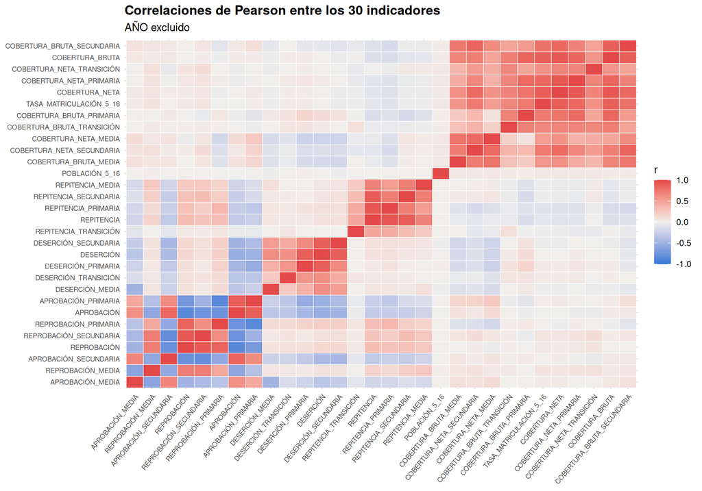

```r
write.csv(R, file.path(tables_dir, "Matriz_correlacion.csv"))

orden <- hclust(as.dist(1 - abs(R)))$order
niveles <- colnames(R)[orden]
cl <- as.data.frame(as.table(R)); names(cl) <- c("V1", "V2", "r")
cl$V1 <- factor(cl$V1, levels = niveles); cl$V2 <- factor(cl$V2, levels = niveles)
p_heatmap <- ggplot(cl, aes(V1, V2, fill = r)) +
  geom_tile(color = "white", linewidth = 0.2) +
  scale_fill_gradient2(low = paleta$azul, mid = "#f0efec", high = "#e34948",
                       midpoint = 0, limits = c(-1, 1), name = "r") +
  tema + theme(axis.text.x = element_text(angle = 50, hjust = 1, size = 7),
               axis.text.y = element_text(size = 7), axis.title = element_blank(),
               panel.grid = element_blank()) +
  labs(title = "Correlaciones de Pearson entre los 30 indicadores", subtitle = "AÑO excluido")
print(p_heatmap)
```

```r
ggsave(file.path(figures_dir, "Heatmap_correlacion.png"), p_heatmap, width = 11, height = 10, dpi = 140)
```

```r
# Reproduce el error anterior: AÑO como columna numérica.
anio_num <- as.numeric(as.character(datos$AÑO))
R_con <- cor(cbind(X, AÑO = anio_num))
r_anio <- R_con["AÑO", names(X)]
comparacion <- data.frame(Indicador = names(X), r_con_AÑO = unname(r_anio))
comparacion <- comparacion[order(-abs(comparacion$r_con_AÑO)), ]
write.csv(comparacion, file.path(tables_dir, "Comparacion_con_sin_anio.csv"), row.names = FALSE)
kable(head(comparacion, 8), digits = 3, row.names = FALSE,
      caption = "Indicadores más asociados al año calendario: esa asociación entraba, sin avisar, en la versión anterior.")
```

Indicadores más asociados al año calendario: esa asociación entraba, sin avisar, en la versión anterior.

| Indicador | r_con_AÑO |
| --- | --- |
| REPITENCIA | 0.659 |
| REPITENCIA_SECUNDARIA | 0.634 |
| REPITENCIA_PRIMARIA | 0.601 |
| REPITENCIA_MEDIA | 0.447 |
| REPROBACIÓN | 0.331 |
| REPROBACIÓN_SECUNDARIA | 0.325 |
| REPITENCIA_TRANSICIÓN | 0.303 |
| APROBACIÓN_SECUNDARIA | -0.264 |

```r
# Mide que parte de cada correlación entre indicadores es tendencia temporal compartida
X_anio <- centrar_por_grupo(X, datos$AÑO)
R_anio <- cor(X_anio)
dif <- abs(R - R_anio)
diag(dif) <- NA
mayor_cambio <- which(dif == max(dif, na.rm = TRUE), arr.ind = TRUE)[1, ]
```

La repitencia (0,66), la repitencia secundaria (0,63) y la primaria (0,60) tienen una tendencia temporal clara. Al restar la media anual de cada indicador (control del año), la correlación entre indicadores cambia en mediana 0,015, pero el cambio máximo es 0,262 (entre REPITENCIA_SECUNDARIA y REPITENCIA_PRIMARIA) y 36 pares cambian más de 0,10. **La estructura general es estable, pero las correlaciones que involucran repitencia incluyen tendencia temporal compartida**; la versión anterior, además, trataba a `AÑO` como un indicador más (con correlaciones de hasta 0,66 con los indicadores).

```r
tri <- which(upper.tri(R), arr.ind = TRUE)
pares_corr <- data.frame(Var1 = rownames(R)[tri[, 1]], Var2 = colnames(R)[tri[, 2]], r = R[tri])
resumen_r <- data.frame(
  umbral = c("|r| >= 0,90", "|r| >= 0,70", "|r| >= 0,50"),
  pares = c(sum(abs(pares_corr$r) >= 0.9), sum(abs(pares_corr$r) >= 0.7), sum(abs(pares_corr$r) >= 0.5)),
  de = nrow(pares_corr))
kable(resumen_r, caption = "Redundancia entre indicadores.")
```

Redundancia entre indicadores.

| umbral | pares | de |
| --- | --- | --- |
| \|r\| >= 0,90 | 5 | 435 |
| \|r\| >= 0,70 | 41 | 435 |
| \|r\| >= 0,50 | 78 | 435 |

## 5. Covarianzas

```r
S <- cov(X)
write.csv(S, file.path(tables_dir, "Matriz_covarianzas.csv"))
varianzas <- data.frame(Variable = names(X), Varianza = diag(S))
varianzas <- varianzas[order(-varianzas$Varianza), ]
kable(head(varianzas, 4), digits = 4, row.names = FALSE,
      caption = "Las cuatro varianzas mayores: POBLACIÓN_5_16 domina por escala.")
```

Las cuatro varianzas mayores: POBLACIÓN_5_16 domina por escala.

| Variable | Varianza |
| --- | --- |
| POBLACIÓN_5_16 | 2.02576e+09 |
| COBERTURA_BRUTA_MEDIA | 7.06000e-02 |
| COBERTURA_BRUTA_TRANSICIÓN | 5.89000e-02 |
| COBERTURA_BRUTA_SECUNDARIA | 5.88000e-02 |

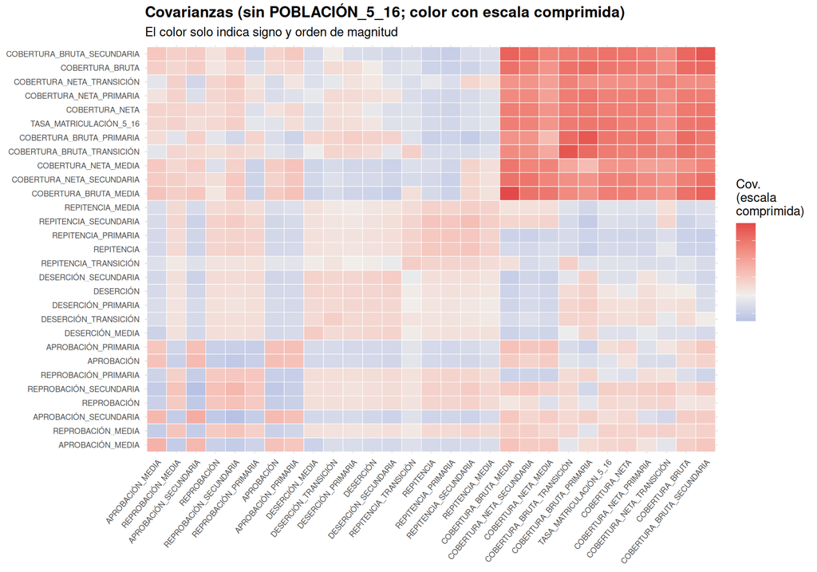

```r
comprimir <- function(x, p = 0.35) sign(x) * abs(x)^p
S_sub <- S[rownames(S) != "POBLACIÓN_5_16", colnames(S) != "POBLACIÓN_5_16"]
S_largo <- as.data.frame(as.table(S_sub)); names(S_largo) <- c("V1", "V2", "Cov")
S_largo$V1 <- factor(S_largo$V1, levels = niveles[niveles != "POBLACIÓN_5_16"])
S_largo$V2 <- factor(S_largo$V2, levels = niveles[niveles != "POBLACIÓN_5_16"])
S_largo$Cov_vis <- comprimir(S_largo$Cov)
p_cov <- ggplot(S_largo, aes(V1, V2, fill = Cov_vis)) +
  geom_tile(color = "white", linewidth = 0.2) +
  scale_fill_gradient2(low = paleta$azul, mid = "#f0efec", high = "#e34948", midpoint = 0,
                       name = "Cov.\n(escala\ncomprimida)", labels = NULL) +
  tema + theme(axis.text.x = element_text(angle = 50, hjust = 1, size = 7),
               axis.text.y = element_text(size = 7), axis.title = element_blank(),
               panel.grid = element_blank()) +
  labs(title = "Covarianzas (sin POBLACIÓN_5_16; color con escala comprimida)",
       subtitle = "El color solo indica signo y orden de magnitud")
print(p_cov)
```

```r
ggsave(file.path(figures_dir, "covarianzas.png"), p_cov, width = 10, height = 9, dpi = 140)
```

La covarianza conserva las unidades: la varianza de `POBLACIÓN_5_16` (2.03e+09) es incomparable con la de las tasas (entre 0 y 1). Por eso la covarianza sirve para construir la distancia de Mahalanobis, pero **no para comparar la fuerza de asociación entre pares**; para eso se usa la correlación.

## 6. Distancias de Mahalanobis

```r
Z <- scale(X)
D2 <- mahalanobis(Z, colMeans(Z), cov(Z))   # distancia al cuadrado
p_var <- ncol(X)
umbral <- qchisq(0.99, df = p_var)
atipico <- D2 > umbral

# Versión sin los indicadores casi colineales (REPROBACIÓN y niveles)
sin_reprob <- setdiff(names(X), grep("^REPROBACIÓN", names(X), value = TRUE))
Zr <- scale(X[, sin_reprob])
D2r <- mahalanobis(Zr, colMeans(Zr), cov(Zr))
umbral_r <- qchisq(0.99, df = length(sin_reprob))

# Versión con el error anterior (AÑO como numérica)
Za <- scale(cbind(X, AÑO = anio_num))
D2a <- mahalanobis(Za, colMeans(Za), cov(Za))
umbral_a <- qchisq(0.99, df = ncol(Za))

top_k <- 100
sol <- function(a, b) length(intersect(order(-a)[1:top_k], order(-b)[1:top_k]))
sens <- data.frame(
  Version = c("Base: 30 indicadores", paste0("Sin REPROBACIÓN (", length(sin_reprob), " indicadores)"),
              "Con AÑO numérico (error anterior)"),
  Variables = c(p_var, length(sin_reprob), ncol(Za)),
  Umbral_chi2_99 = c(umbral, umbral_r, umbral_a),
  Marcados = c(sum(atipico), sum(D2r > umbral_r), sum(D2a > umbral_a)),
  Pct_marcados = 100 * c(mean(atipico), mean(D2r > umbral_r), mean(D2a > umbral_a)),
  Coinciden_top100_con_base = c(top_k, sol(D2, D2r), sol(D2, D2a))
)
write.csv(sens, file.path(tables_dir, "Mahalanobis_sensibilidad.csv"), row.names = FALSE)
kable(sens, digits = 2, caption = "Mahalanobis: versión base y verificaciones de sensibilidad.")
```

Mahalanobis: versión base y verificaciones de sensibilidad.

| Version | Variables | Umbral_chi2_99 | Marcados | Pct_marcados | Coinciden_top100_con_base |
| --- | --- | --- | --- | --- | --- |
| Base: 30 indicadores | 30 | 50.89 | 1190 | 8.62 | 100 |
| Sin REPROBACIÓN (26 indicadores) | 26 | 45.64 | 1281 | 9.28 | 92 |
| Con AÑO numérico (error anterior) | 31 | 52.19 | 1174 | 8.51 | 100 |

```r
dist_df <- data.frame(Fila = seq_len(nrow(X)), AÑO = as.character(datos$AÑO),
                      MUNICIPIO = datos$MUNICIPIO, DEPARTAMENTO = datos$DEPARTAMENTO,
                      Mahalanobis_D2 = D2, Atipico = atipico)
write.csv(dist_df, file.path(tables_dir, "Distancias_Mahalanobis.csv"), row.names = FALSE)
```

Bajo normalidad multivariada, D² sigue una χ² con 30 grados de libertad y solo un **1 %** de los registros superaría el percentil 99 (50,9). Aquí lo supera el **8,6 %** (1.190 registros): los indicadores son acotados, asimétricos y con muchos ceros, así que el supuesto no se cumple y **el umbral χ² marca de más**. Úselo como ranking de rareza relativa, no como prueba de anomalía.

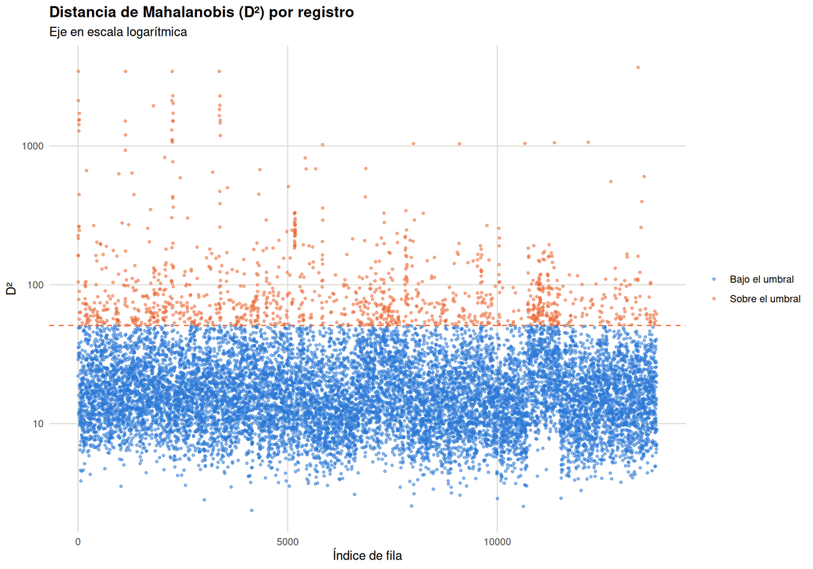

```r
umbral_graf <- umbral
p_indice <- ggplot(dist_df, aes(Fila, Mahalanobis_D2, color = Atipico)) +
  geom_point(alpha = 0.5, size = 0.8) +
  geom_hline(yintercept = umbral_graf, linetype = "dashed", color = paleta$naranja) +
  scale_color_manual(values = c("FALSE" = paleta$azul, "TRUE" = paleta$naranja),
                     labels = c("Bajo el umbral", "Sobre el umbral")) +
  scale_y_log10() +
  tema + labs(title = "Distancia de Mahalanobis (D²) por registro", subtitle = "Eje en escala logarítmica",
              y = "D²", x = "Índice de fila", color = NULL)
print(p_indice)
```

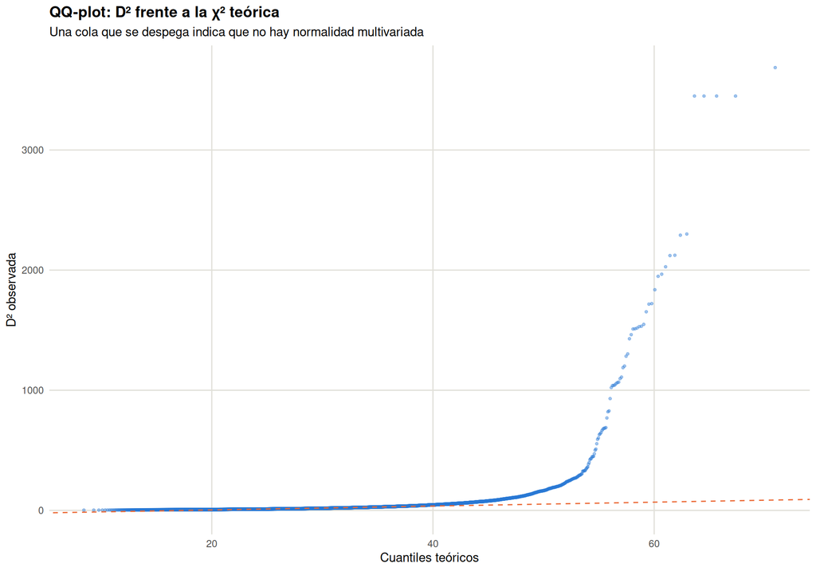

```r
ggsave(file.path(figures_dir, "mahalanobis_indice.png"), p_indice, width = 11, height = 5.5, dpi = 150)

p_qq <- ggplot(dist_df, aes(sample = Mahalanobis_D2)) +
  stat_qq(distribution = qchisq, dparams = list(df = p_var), color = paleta$azul, alpha = 0.4, size = 0.8) +
  stat_qq_line(distribution = qchisq, dparams = list(df = p_var), color = paleta$naranja, linetype = "dashed") +
  tema + labs(title = "QQ-plot: D² frente a la χ² teórica", subtitle = "Una cola que se despega indica que no hay normalidad multivariada",
              x = "Cuantiles teóricos", y = "D² observada")
print(p_qq)
```

```r
ggsave(file.path(figures_dir, "mahalanobis_qqplot.png"), p_qq, width = 7, height = 7, dpi = 150)
```

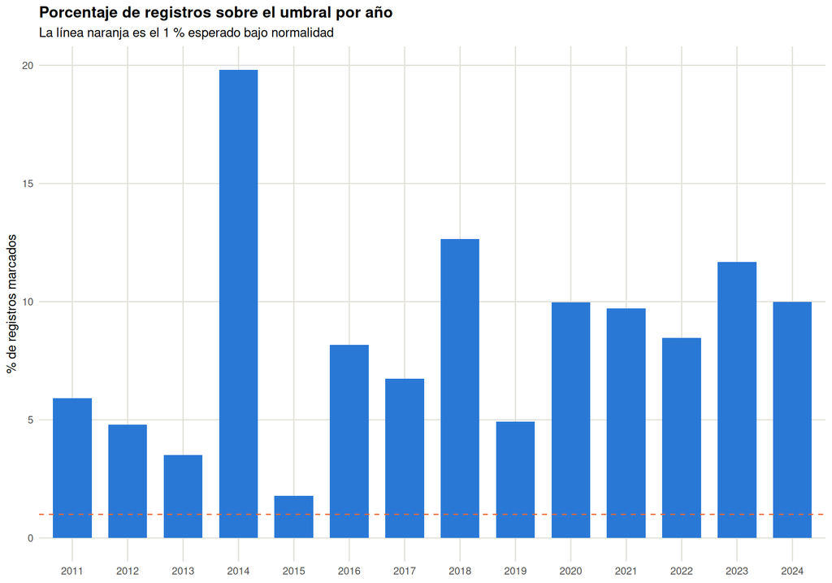

```r
por_anio <- dist_df %>% group_by(AÑO) %>%
  summarise(Registros = n(), Marcados = sum(Atipico), Pct_marcados = 100 * mean(Atipico), .groups = "drop")
write.csv(por_anio, file.path(tables_dir, "Mahalanobis_por_anio.csv"), row.names = FALSE)

p_anio <- ggplot(por_anio, aes(AÑO, Pct_marcados)) +
  geom_col(fill = paleta$azul, width = 0.7) +
  geom_hline(yintercept = 1, linetype = "dashed", color = paleta$naranja) +
  tema + labs(title = "Porcentaje de registros sobre el umbral por año",
              subtitle = "La línea naranja es el 1 % esperado bajo normalidad", x = NULL, y = "% de registros marcados")
print(p_anio)
```

```r
ggsave(file.path(figures_dir, "mahalanobis_por_anio.png"), p_anio, width = 10, height = 5, dpi = 150)

top10 <- dist_df[order(-dist_df$Mahalanobis_D2), ][1:10, c("AÑO", "MUNICIPIO", "DEPARTAMENTO", "Mahalanobis_D2")]
kable(top10, digits = 1, row.names = FALSE, caption = "Diez registros con mayor distancia (candidatos a revisión, no diagnósticos). Los registros de Papunaua tienen todos los indicadores en cero.")
```

Diez registros con mayor distancia (candidatos a revisión, no diagnósticos). Los registros de Papunaua tienen todos los indicadores en cero.

| AÑO | MUNICIPIO | DEPARTAMENTO | Mahalanobis_D2 |
| --- | --- | --- | --- |
| 2011 | Albania | La Guajira | 3685.8 |
| 2021 | Papunaua | Vaupés | 3449.2 |
| 2023 | Papunaua | Vaupés | 3449.2 |
| 2024 | Papunaua | Vaupés | 3449.2 |
| 2022 | Papunaua | Vaupés | 3449.2 |
| 2022 | La Guadalupe | Guainía | 2300.8 |
| 2021 | La Guadalupe | Guainía | 2290.9 |
| 2023 | Puerto Colombia | Guainía | 2124.0 |
| 2024 | Taraira | Vaupés | 2121.2 |
| 2022 | La Victoria | Amazonas | 2027.9 |

El porcentaje marcado varía entre 1,8 % y 19,8 % según el año (el año con más marcados es 2014). Una fila lejana del centro multivariado puede reflejar un municipio pequeño con tasas inestables, un valor fuera de rango (coberturas > 1) o una combinación inusual de indicadores. **«Atípico» describe distancia, no crisis ni error.** En las versiones de sensibilidad coinciden con la base 92 de los 100 registros más lejanos (sin REPROBACIÓN) y 100 (con el error de `AÑO`): el ranking de rareza es robusto a ambos cambios, aunque el número de marcados varía.

## 7. Conclusiones corregidas

1. **Selección de variables.** El análisis multivariado usa 30 indicadores; `AÑO` y los identificadores quedan fuera. La versión anterior mezclaba una variable temporal con los indicadores.
2. **Datos.** 13.802 registros municipio-año de 1.123 municipios, sin faltantes, constantes ni duplicados; no corresponde tratarlos como observaciones independientes.
3. **Correlación.** 5 pares superan |r| = 0,90 y 41 superan 0,70: hay bloques redundantes. La estructura general es estable al controlar el año, salvo en los pares con repitencia.
4. **Condicionamiento.** La matriz es invertible pero casi singular (aprobación + reprobación + deserción ≈ 1). Se recomienda trabajar con pocos representantes por bloque, como en el taller de PCA.
5. **Mahalanobis.** 8,6 % de registros supera el umbral χ² (esperado 1 %), por incumplimiento de normalidad; sirve como ranking. Las distancias no distinguen error de captura de municipio pequeño o situación real.
6. **Las 33 columnas.** Con one-hot, «ambos» (departamentos y municipios) deja 35 dependencias exactas y no se puede invertir; las categóricas no entran a Mahalanobis.
7. **Ceros sospechosos.** 4 registros (Papunaua) tienen todos los indicadores de tasa en cero; figuran entre los cinco registros de mayor distancia de Mahalanobis y probablemente son datos ausentes codificados como 0.
8. **Pendiente de validación.** Revisión de los registros con coberturas > 100 %, causa del cambio de nivel desde 2020 y evaluación con una distancia robusta (MCD) o por municipio; ninguna se hizo en este taller.